# preprocessing

# Loading

Loading useful packages

```r
library(tidyverse)
```

```r
library(ggplot2)
```

The centred log-ratio is defined by hand so that the transformation is transparent and has no hidden zero handling. It is identical to `compositions::clr()` for strictly positive compositions.

```r
clr <- function(x) {
  stopifnot(all(x > 0))
  lx <- log(x)
  lx - mean(lx)
}
```

Loading raw data

```r
raw_data <- read.csv("validations-reseau-ferre-profils-horaires-par-jour-type-2eme-trimestre.csv", sep = ";")
colnames(raw_data)
```

```
## [1] "CODE_STIF_TRNS"          "CODE_STIF_RES"
## [3] "CODE_STIF_ARRET"         "ID_ZDC"
## [5] "LIBELLE_ARRET"           "CAT_JOUR"
## [7] "TRNC_HORR_60"            "Pourcentage_validations"
```

# Recovering altered data

```r
raw_data <- raw_data %>% mutate(
  ID_ZDC = if_else((
    CODE_STIF_ARRET == "ND" &
      CAT_JOUR == "SAVS" &
      CODE_STIF_TRNS == "100"
  ),
  71799,
  ID_ZDC
  ),
  LIBELLE_ARRET = if_else((
    CODE_STIF_ARRET == "ND" &
      CAT_JOUR == "SAVS" &
      CODE_STIF_TRNS == "100"
  ),
  "PTE D.BAGNOLET",
  LIBELLE_ARRET
  ),
  CODE_STIF_RES = if_else((
    CODE_STIF_ARRET == "ND" &
      CAT_JOUR == "SAVS" &
      CODE_STIF_TRNS == "100"
  ),
  "110",
  CODE_STIF_RES
  ),

  CODE_STIF_ARRET = if_else((
    CODE_STIF_ARRET == "ND" &
      CAT_JOUR == "SAVS" &
      CODE_STIF_TRNS == "100"
  ),
  "684",
  CODE_STIF_ARRET
  )
)
```

# Column selection and translation

Selecting appropriate columns and translating them

```r
data <- raw_data %>% mutate(
  station_id = paste(
    CODE_STIF_TRNS,
    CODE_STIF_RES,
    CODE_STIF_ARRET,
    sep = "_")
) %>% select(
  station_id,
  ID_ZDC,
  LIBELLE_ARRET,
  CAT_JOUR,
  TRNC_HORR_60,
  Pourcentage_validations
) %>% rename(
  connection_id = ID_ZDC,
  station_name = LIBELLE_ARRET,
  day_cat = CAT_JOUR,
  time_slot = TRNC_HORR_60,
  percentage_entering = Pourcentage_validations
)

head(data)
```

```
##    station_id connection_id   station_name day_cat time_slot
## 1 100_110_754         71326 GDS BOULEVARDS    JOVS   11H-12H
## 2 100_110_754         71326 GDS BOULEVARDS    JOVS   15H-16H
## 3 100_110_754         71326 GDS BOULEVARDS    JOVS     2H-3H
## 4 100_110_754         71326 GDS BOULEVARDS    JOVS     5H-6H
## 5 100_110_754         71326 GDS BOULEVARDS    JOVS     8H-9H
## 6 100_110_754         71326 GDS BOULEVARDS    SAHV     1H-2H
##   percentage_entering
## 1                3.21
## 2                5.29
## 3                0.01
## 4                0.22
## 5                3.66
## 6                2.87
```

```r
unique(data %>% pull(time_slot))
```

```
##  [1] "11H-12H" "15H-16H" "2H-3H"   "5H-6H"   "8H-9H"   "1H-2H"   "21H-22H"
##  [8] "7H-8H"   "4H-5H"   "12H-13H" "22H-23H" "23H-0H"  "9H-10H"  "16H-17H"
## [15] "13H-14H" "17H-18H" "0H-1H"   "18H-19H" "19H-20H" "10H-11H" "14H-15H"
## [22] "20H-21H" "6H-7H"   "3H-4H"   "ND"
```

Transforming time slots into start time points

```r
ts_to_stp <- c(
  "0H-1H"= 0,
  "1H-2H"= 1,
  "2H-3H"= 2,
  "3H-4H"= 3,
  "4H-5H"= 4,
  "5H-6H"= 5,
  "6H-7H"= 6,
  "7H-8H"= 7,
  "8H-9H"= 8,
  "9H-10H"= 9,
  "10H-11H"= 10,
  "11H-12H"= 11,
  "12H-13H"= 12,
  "13H-14H"= 13,
  "14H-15H"= 14,
  "15H-16H"= 15,
  "16H-17H"= 16,
  "17H-18H"= 17,
  "18H-19H"= 18,
  "19H-20H"= 19,
  "20H-21H"= 20,
  "21H-22H"= 21,
  "22H-23H"= 22,
  "23H-0H"= 23
)

data <- data %>% mutate(
  time_slot = ts_to_stp[time_slot]
)
```

Translate day categories:

- WD: Working day (outside of school holidays periods)
- WDSH: Working day during school holidays
- SA: Saturday (outside of school holidays periods)
- SASH: Saturday during school holidays
- SUPH: Sunday and bank holidays

```r
translate_day_cat <- c(
  "JOHV" = "WD",
  "JOVS" = "WDSH",
  "SAHV" = "SA",
  "SAVS" = "SASH",
  "DIJFP" = "SUPH"
)

data <- data %>% mutate(
  day_cat = translate_day_cat[day_cat]
)
```

# Removing wrong data

## Removing non-defined data

Removing unknown stations

```r
data <- data %>% filter(station_name != "Inconnu")
```

Checking `connection_id`

```r
any(is.na(data$connection_id))
```

```
## [1] TRUE
```

There are non-defined connections, let’s inspect them

```r
data %>% filter(is.na(connection_id))
```

```
##           station_id connection_id    station_name day_cat time_slot
## 1   760_760_00490909            NA Aéroport d'Orly    SUPH        10
## 2   760_760_00490909            NA Aéroport d'Orly    SUPH        12
## 3   760_760_00490909            NA Aéroport d'Orly    SUPH        14
## 4   760_760_00490909            NA Aéroport d'Orly    SUPH        18
## 5   760_760_00490909            NA Aéroport d'Orly    SUPH         6
## 6   760_760_00490909            NA Aéroport d'Orly    SUPH         7
## 7   760_760_00490909            NA Aéroport d'Orly    SUPH         9
## 8   760_760_00490909            NA Aéroport d'Orly      WD        12
## 9   760_760_00490909            NA Aéroport d'Orly      WD        13
## 10  760_760_00490909            NA Aéroport d'Orly      WD        14
## 11  760_760_00490909            NA Aéroport d'Orly      WD        18
## 12  760_760_00490909            NA Aéroport d'Orly      WD        22
## 13  760_760_00490909            NA Aéroport d'Orly      WD         3
## 14  760_760_00490909            NA Aéroport d'Orly      WD         4
```

[output cut: 225 more lines]

It is normal since there are no connection zone in the Orly Airport, we will handle it later.

Checking that there is only one `station_name` per `station_id`

```r
data %>% select(station_id, station_name) %>% group_by(station_id) %>% distinct(station_name) %>% count() %>% filter(n != 1)
```

```
## # A tibble: 0 × 2
## # Groups:   station_id [0]
## # ℹ 2 variables: station_id <chr>, n <int>
```

Checking `day_cat`

```r
unique(data$day_cat)
```

```
## [1] "WDSH" "SA"   "SASH" "SUPH" "WD"
```

Checking `time_slot`

```r
data %>% filter(is.na(time_slot))
```

```
##       station_id connection_id   station_name day_cat time_slot
## 1    800_804_196         62558 COMBS LA VILLE      WD        NA
## 2 100_110_490773        426280   ROSNY BOIS.P      WD        NA
## 3    100_110_313         71359  GARE DE L'EST      WD        NA
## 4    810_801_577         70945 NANTERRE-PREF.    WDSH        NA
## 5    810_801_163         71264       CHATELET    SUPH        NA
## 6    100_110_313         71359  GARE DE L'EST    SUPH        NA
## 7    100_110_695         71084   PTE ST-CLOUD      WD        NA
##   percentage_entering
## 1                   0
## 2                   0
## 3                   0
## 4                   0
## 5                   0
## 6                   0
## 7                   0
```

The corresponding percentage is null, they do not carry information so we discard them

```r
data <- data %>% filter(!is.na(time_slot))
```

Inspecting `percentage_entering`

```r
data %>% filter(is.na(percentage_entering) | percentage_entering < 0 & percentage_entering > 100)
```

```
## [1] station_id          connection_id       station_name
## [4] day_cat             time_slot           percentage_entering
## <0 rows> (or 0-length row.names)
```

Checking that all day types exists for each station

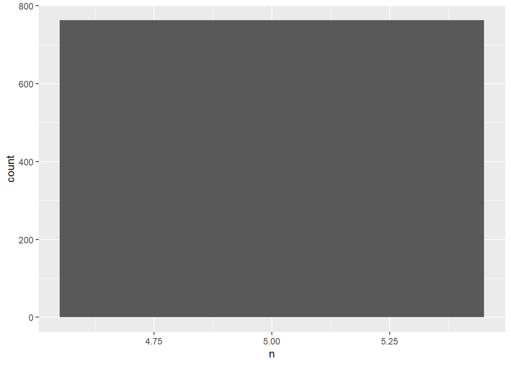

```r
data %>% select(station_id, day_cat) %>% distinct() %>% group_by(station_id) %>% count() %>% ggplot(data = ., aes(n)) + geom_bar()
```

## Removing inconsistent data

Checking that all distributions sum up to 100%

[output not shown]

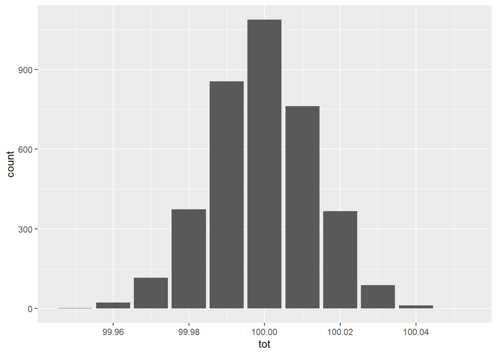

```r
data %>% group_by(station_id, day_cat) %>% summarise(tot = sum(percentage_entering)) %>% ggplot(data = ., aes(tot)) + geom_bar()
```

There is some inconsistency (probably associated to number rounding), we will correct it later. Checking if all points exists

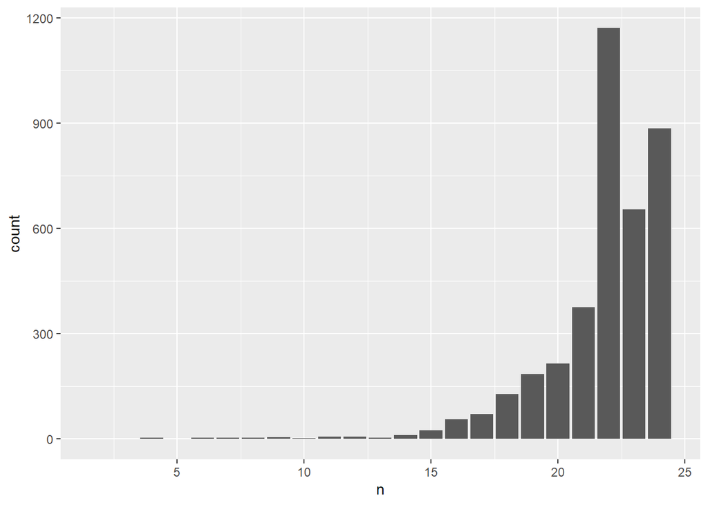

```r
data %>% group_by(station_id, day_cat) %>% count() %>% ggplot(data = ., aes(n)) + geom_bar()
```

Checking which time point is mostly missing

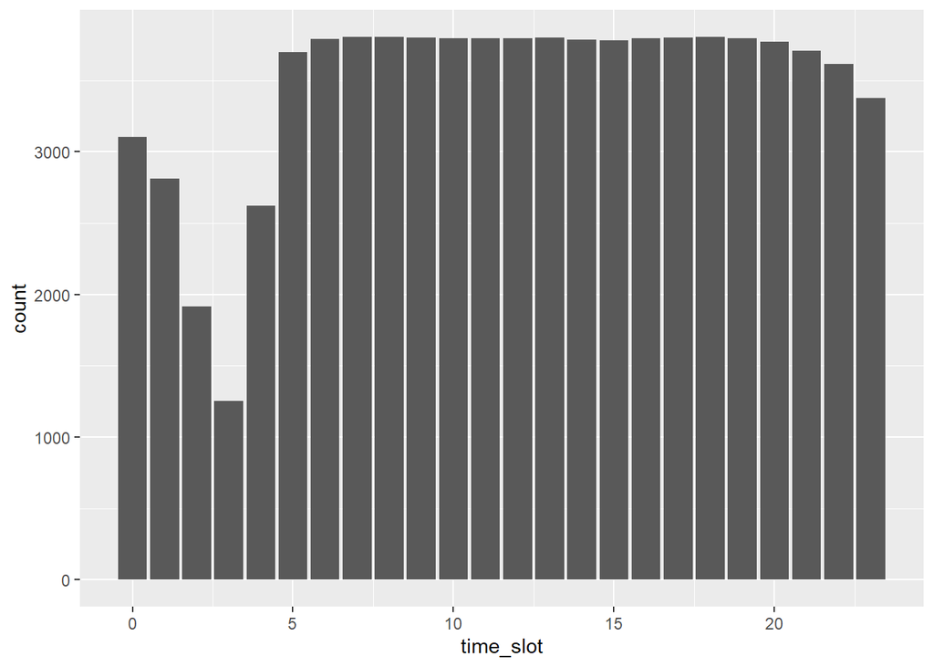

```r
ggplot(data, aes(time_slot)) + geom_bar()
```

Given that every distributions sums up to approximately 100%, we can add missing points by giving them a zero value.

```r
data <- data %>% complete(
  time_slot,
  day_cat,
  nesting(station_id,
          connection_id,
          station_name
  ),
  fill = list(percentage_entering = 0.)
)
```

Checking zero values

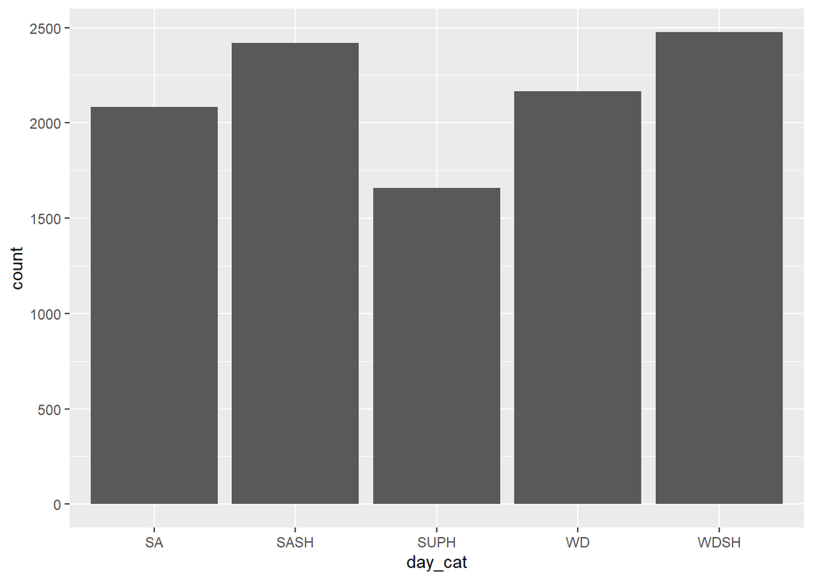

```r
data %>% filter(percentage_entering == 0) %>% ggplot(data = ., aes(day_cat)) + geom_bar()
```

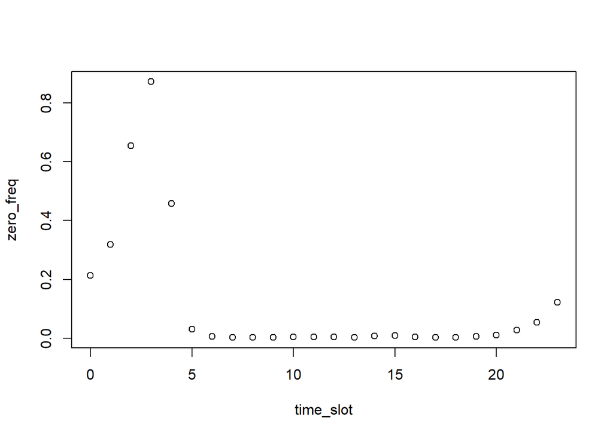

```r
data %>% group_by(time_slot) %>% summarize(zero_freq = mean(percentage_entering  == 0)) %>% plot()
```

There is no clear cut-off, we transform all zero values in near-zero values. Shares are reported with two decimals, so a recorded 0 means a true share below 0.005%. We replace it with 0.01 and keep an explicit `imputed` flag, so that later steps know exactly which values are replacements (a genuine 0.01 and an imputed one are otherwise indistinguishable).

```r
imputation_value <- 0.01

data <- data %>% mutate(
  imputed = percentage_entering == 0,
  percentage_entering = ifelse(imputed, imputation_value, percentage_entering)
)

mean(data$imputed)
```

```
## [1] 0.11801
```

We check normalization

[output not shown]

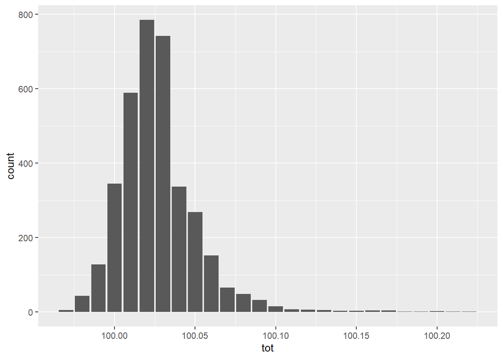

```r
data %>% group_by(station_id, day_cat) %>% summarise(tot = sum(percentage_entering)) %>% ggplot(data = ., aes(tot)) + geom_bar()
```

```r
data %>% group_by(station_id, day_cat) %>% summarise(error = (sum(percentage_entering)-100)/0.01)
```

[output not shown]

```
## # A tibble: 3,815 × 3
## # Groups:   station_id [763]
##    station_id day_cat error
##    <chr>      <chr>   <dbl>
##  1 100_110_1  SA       2.00
##  2 100_110_1  SASH     2.00
##  3 100_110_1  SUPH     0
##  4 100_110_1  WD       1.00
##  5 100_110_1  WDSH     2.00
##  6 100_110_10 SA       2.00
##  7 100_110_10 SASH     4.00
##  8 100_110_10 SUPH     2.00
##  9 100_110_10 WD       2.00
## 10 100_110_10 WDSH     1.00
## # ℹ 3,805 more rows
```

The totals differ from 100 because of rounding and of the zero replacement. We **close** each composition deterministically, $x \mapsto 100\,x/\sum_t x_t$.

An earlier version corrected the rounding error by subtracting random multinomial draws of 0.01. That approach had two problems: it could push imputed 0.01 values back to exactly 0 (which makes the CLR infinite), and, without a seed, it changed the data on every knit. Closure avoids both. It keeps every value strictly positive, it is reproducible, and it does not change the CLR at all, because the CLR is scale invariant: $\mathrm{clr}(c\,x)=\mathrm{clr}(x)$.

```r
data <- data %>%
  group_by(station_id, day_cat) %>%
  mutate(percentage_entering = 100 * percentage_entering / sum(percentage_entering)) %>%
  ungroup()

data %>%
  group_by(station_id, day_cat) %>%
  summarise(tot = sum(percentage_entering), .groups = "drop") %>%
  summarise(max_abs_error = max(abs(tot - 100)),
            min_share = min(data$percentage_entering))
```

```
## # A tibble: 1 × 2
##   max_abs_error min_share
##           <dbl>     <dbl>
## 1      1.42e-14   0.00998
```

# Creating useful data containers

3D array with rows as stations, columns as day types and cells (or depth) as the hourly distribution

```r
to_array_3d <- function(data, value_col) {
  data %>% select(
    station_id,
    day_cat,
    time_slot,
    all_of(value_col)
  ) %>% pivot_wider(
    names_from = day_cat,
    values_from = all_of(value_col)
  ) %>% {split(.[setdiff(names(.), "time_slot")], .$time_slot)} %>%
    map(~ .x %>%
          column_to_rownames('station_id') %>%
          as.matrix) %>%
    simplify2array
}

array_3d <- to_array_3d(data, "percentage_entering")
array_3d_imputed <- to_array_3d(data, "imputed")   # TRUE where a 0 was replaced

stopifnot(identical(dimnames(array_3d), dimnames(array_3d_imputed)))
```

3D array with Centred Log Ratio Transformation applied (full day, 24 hours)

```r
array_3d_clr <- aperm(apply(array_3d, c(1, 2), clr), c(2, 3, 1))
dimnames(array_3d_clr) <- dimnames(array_3d)
```

## CLR on service hours

```r
imputed_by_hour <- apply(array_3d_imputed, c(2, 3), mean)
round(imputed_by_hour, 2)
```

```
##         0    1    2    3    4    5    6    7    8    9   10   11   12   13   14
## SA   0.17 0.27 0.60 0.93 0.48 0.04 0.01 0.00 0.00 0.00 0.00 0.00 0.00 0.00 0.01
## SASH 0.21 0.36 0.63 0.95 0.53 0.07 0.01 0.01 0.01 0.01 0.01 0.01 0.01 0.01 0.01
## SUPH 0.17 0.23 0.48 0.66 0.44 0.02 0.01 0.00 0.00 0.00 0.00 0.00 0.00 0.00 0.00
## WD   0.24 0.36 0.77 0.91 0.37 0.00 0.00 0.00 0.00 0.00 0.00 0.00 0.00 0.00 0.00
## WDSH 0.28 0.38 0.78 0.90 0.46 0.02 0.00 0.00 0.01 0.00 0.01 0.01 0.01 0.01 0.01
##        15   16   17   18   19   20   21   22   23
## SA   0.01 0.01 0.00 0.00 0.00 0.01 0.02 0.05 0.09
## SASH 0.01 0.01 0.01 0.01 0.01 0.02 0.05 0.08 0.14
## SUPH 0.01 0.00 0.00 0.00 0.00 0.00 0.02 0.03 0.09
## WD   0.00 0.00 0.00 0.00 0.00 0.00 0.01 0.04 0.11
## WDSH 0.01 0.01 0.01 0.01 0.01 0.02 0.04 0.08 0.19
```

We keep the hours in which, for **every** day type, at most 25% of the values are replacements. Because the CLR is not subcompositionally coherent, we re-close the subcomposition on those hours before taking the CLR. Simply dropping columns of the full-day CLR would be wrong.

```r
hours_all <- as.integer(dimnames(array_3d)[[3]])
hours_service <- hours_all[apply(imputed_by_hour, 2, max) <= 0.25]
hours_service
```

```
##  [1]  5  6  7  8  9 10 11 12 13 14 15 16 17 18 19 20 21 22 23
```

```r
array_3d_service <- array_3d[, , as.character(hours_service)]
array_3d_service <- sweep(array_3d_service, c(1, 2),
                          apply(array_3d_service, c(1, 2), sum), "/") * 100
array_3d_clr_service <- aperm(apply(array_3d_service, c(1, 2), clr), c(2, 3, 1))
dimnames(array_3d_clr_service) <- dimnames(array_3d_service)
```

## Integrity checks

```r
checks <- c(
  all_shares_positive        = all(array_3d > 0),
  full_day_sums_to_100       = max(abs(apply(array_3d, c(1, 2), sum) - 100)) < 1e-8,
  full_day_clr_finite        = all(is.finite(array_3d_clr)),
  full_day_clr_sums_to_0     = max(abs(apply(array_3d_clr, c(1, 2), sum))) < 1e-8,
  service_sums_to_100        = max(abs(apply(array_3d_service, c(1, 2), sum) - 100)) < 1e-8,
  service_clr_finite         = all(is.finite(array_3d_clr_service)),
  service_clr_sums_to_0      = max(abs(apply(array_3d_clr_service, c(1, 2), sum))) < 1e-8,
  # scale invariance: CLR of the un-closed service shares is the same
  service_clr_scale_invariant = isTRUE(all.equal(
    array_3d_clr_service,
    {
      raw <- array_3d[, , as.character(hours_service)]
      out <- aperm(apply(raw, c(1, 2), clr), c(2, 3, 1))
      dimnames(out) <- dimnames(raw)
      out
    }
  ))
)
checks
```

```
##         all_shares_positive        full_day_sums_to_100
##                        TRUE                        TRUE
##         full_day_clr_finite      full_day_clr_sums_to_0
##                        TRUE                        TRUE
##         service_sums_to_100          service_clr_finite
##                        TRUE                        TRUE
##       service_clr_sums_to_0 service_clr_scale_invariant
##                        TRUE                        TRUE
```

```r
stopifnot(all(checks))
```

Tibble with station information

```r
stations <- data %>% select(
  station_id,
  connection_id,
  station_name
) %>% distinct()
```

# Saving cleaned data for next steps

```r
write.csv(data, "cleaned_data.csv", row.names = FALSE)
write.csv(stations, "stations.csv", row.names = FALSE)
save(array_3d, array_3d_imputed, file = "array_3d.rda")
save(array_3d_clr, file = "array_3d_clr.rda")
save(array_3d_clr_service, array_3d_service, hours_service,
     file = "array_3d_clr_service.rda")
```

To load data contained in `.rda` files, use for example `load("array_3d.rda")`. It will load `array_3d` (and `array_3d_imputed`) in the environment.

| File | Objects | Use |
| --- | --- | --- |
| `array_3d.rda` | `array_3d`, `array_3d_imputed` | closed shares (%), 24 hours, and the replacement mask |
| `array_3d_clr.rda` | `array_3d_clr` | CLR on the full day (sensitivity analyses only) |
| `array_3d_clr_service.rda` | `array_3d_clr_service`, `array_3d_service`, `hours_service` | **CLR on service hours: use this for depth and biclustering** |